# Answering Business Questions using SQL

Dennis Jonathan

5/13/2021

Now we will try and use some of the skills that we have learned during the SQL courses to answer some business questions. We will be using the famous [`chinook.db`](https://dsserver-prod-resources-1.s3.amazonaws.com/374/chinook.db) dataset as the foundation of our project.

We’ll be working with a modified version of a database called Chinook. The Chinook database contains information about a fictional digital music shop - kind of like a mini-iTunes store.

## Prerequisites

```r
# Shutting off warning messages
options(warn=-1)

# Importing the libraries
library(tidyverse)
library(DBI)
library(RSQLite)
```

## Creating Some Helper Functions

Before we begin, we might want to define some functions to reduce the amount of repetitive codes that we might call, some example includes querying and also previewing the data that we can play with.

```r
# Defining a function to import the data from sqlite
run_query <- function(query){
  conn <- dbConnect(SQLite(),'chinook.db')
  result <- dbGetQuery(conn, query)
  dbDisconnect(conn)
  result
}

# Previewing all tables
show_tables <- function() {
  q = "SELECT name, type FROM sqlite_master WHERE type IN ('table', 'view')"
  return(run_query(q))
}

show_tables()
```

```
##              name  type
## 1           album table
## 2          artist table
## 3        customer table
## 4        employee table
## 5           genre table
## 6         invoice table
## 7    invoice_line table
## 8      media_type table
## 9        playlist table
## 10 playlist_track table
## 11          track table
```

As we can see, we have created two functions that will make our live easier down the road.

## Analysis

### 1. Genre recommendation

We will try and give some recommendations for the genre which our store shoul purchase. To do this, we will find the percentage share for the genres based on our historical data. We are also presented with the choice of purchasing albums from some artists, those artists are:

| **Artist Name** | **Genre** |
| --- | --- |
| Regal | Hip-Hop |
| Red Tone | Punk |
| Meteor and the Girls | Pop |
| Slim Jim Bites | Blues |

```r
# Writing the query
query1 <- "
WITH cus_invo AS
    (
    SELECT
        g.name genre
    FROM customer c
    INNER JOIN invoice i ON i.customer_id=c.customer_id
    INNER JOIN invoice_line il ON il.invoice_id=i.invoice_id
    INNER JOIN track t ON t.track_id=il.track_id
    INNER JOIN genre g ON g.genre_id=t.genre_id
    WHERE c.country='USA'
    )

SELECT
    genre,
    COUNT(genre) total_sold,
    ROUND(CAST(COUNT(genre) AS float)/(SELECT COUNT(*) FROM cus_invo),4) percentage_share
FROM cus_invo
GROUP BY 1
ORDER By 2 DESC;
"

# Storing the query
genre_rec <- run_query(query1)

# Previewing the result
genre_rec
```

```
##                 genre total_sold percentage_share
## 1                Rock        561           0.5338
## 2  Alternative & Punk        130           0.1237
## 3               Metal        124           0.1180
## 4            R&B/Soul         53           0.0504
## 5               Blues         36           0.0343
## 6         Alternative         35           0.0333
## 7                 Pop         22           0.0209
## 8               Latin         22           0.0209
## 9         Hip Hop/Rap         20           0.0190
## 10               Jazz         14           0.0133
## 11     Easy Listening         13           0.0124
## 12             Reggae          6           0.0057
## 13  Electronica/Dance          5           0.0048
## 14          Classical          4           0.0038
## 15        Heavy Metal          3           0.0029
## 16         Soundtrack          2           0.0019
## 17           TV Shows          1           0.0010
```

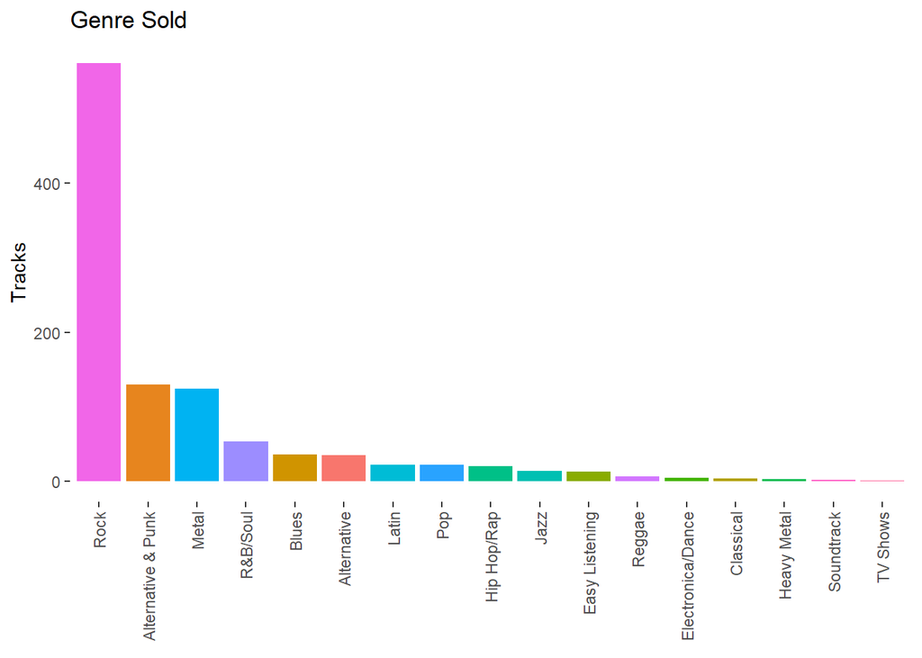

```r
# Plotting the query
genre_rec %>% ggplot(aes(x = reorder(genre, -total_sold), y = total_sold, fill = genre)) + geom_col() +
                     labs(title = 'Genre Sold', y = 'Tracks', x = element_blank()) +
                     theme(panel.background = element_rect(fill = "white"), axis.text.x = element_text(angle = 90, vjust = 0.5, hjust=1), legend.position = "none")
```

The graph indicates that the Rock Genre is the highest selling genre in the United States with alternative & punk trailing in second. Thus, purchasing Red Tone’s albums would be wise since the genre is the second favorite in the US.

### 2. Anaylyzing sales agent

Each customer for the Chinook store gets assigned to a sales support agent within the company when they first make a purchase. We have been asked to analyze the purchases of customers belonging to each employee to see if any sales support agent is performing either better or worse than the others.

```r
# Writing the query
query2 <- "
WITH
    cus_inv AS
    (
    SELECT
        c.support_rep_id,
        SUM(i.total) total_purchases
    FROM customer c
    INNER JOIN invoice i ON i.customer_id=c.customer_id
    GROUP BY c.customer_id)

SELECT
    e.first_name||' '||e.last_name employee_name,
    e.hire_date,
    ROUND(SUM(ci.total_purchases),2) total_contribution
FROM employee e
INNER JOIN cus_inv ci ON ci.support_rep_id=e.employee_id
GROUP BY e.employee_id
ORDER BY total_contribution DESC;
"
# Getting the data from SQL
sales_agent <- run_query(query2)

# Previewing the result
sales_agent
```

```
##   employee_name           hire_date total_contribution
## 1  Jane Peacock 2017-04-01 00:00:00            1731.51
## 2 Margaret Park 2017-05-03 00:00:00            1584.00
## 3 Steve Johnson 2017-10-17 00:00:00            1393.92
```

A quick observation tells us that Jane Peacock is the highest contributing sales agent with 1731.51 dollars and Steve Johnson is the lowest at 1393.92 dollars. There seems to be a correlation between the hire date and the total contribution where older employees tend to contribute more than newer employees.

### 3. Sales from other countries

Here we want to see where our customers are from (the country) and how much they spend in that country. This can be useful if we decide to expand to that particular country or decide to increase sales there.

```r
# Writing the query
query3 <- "
WITH country_c AS
    (
    SELECT
        CASE
            WHEN (SELECT COUNT(*) FROM customer
                 WHERE country=c.country)=1 THEN 'Other'
            ELSE c.country
        END AS country,
        COUNT(DISTINCT c.customer_id) n_customer,
        ROUND(SUM(il.unit_price),2) total_value,
        ROUND(SUM(il.unit_price)/COUNT(DISTINCT i.invoice_id),2) average_order_Value
    FROM invoice_line il
    INNER JOIN invoice i ON i.invoice_id=il.invoice_id
    INNER JOIN customer c ON c.customer_id=i.customer_id
    GROUP BY 1
    )
SELECT
    country,
    n_customer,
    total_value,
    ROUND(total_value/n_customer,2) average_value_per_customer,
    average_order_value
FROM
    (
    SELECT
        cc.*,
        CASE
            WHEN cc.country = 'Other' THEN 1
            ELSE 0
        END AS sort
    FROM country_c cc
   )
ORDER BY 4 DESC;
"

# Running the query
country <- run_query(query3)

# Previewing the result
country
```

```
##           country n_customer total_value average_value_per_customer
## 1  Czech Republic          2      273.24                     136.62
## 2        Portugal          2      185.13                      92.57
## 3           India          2      183.15                      91.58
## 4          Brazil          5      427.68                      85.54
## 5         Germany          4      334.62                      83.66
## 6  United Kingdom          3      245.52                      81.84
## 7             USA         13     1040.49                      80.04
## 8          France          5      389.07                      77.81
## 9           Other         15     1094.94                      73.00
## 10         Canada          8      535.59                      66.95
##    average_order_Value
## 1                 9.11
## 2                 6.38
## 3                 8.72
## 4                 7.01
## 5                 8.16
## 6                 8.77
## 7                 7.94
## 8                 7.78
## 9                 7.45
## 10                7.05
```

Based on the table above, we can clearly see that there is a room for improvement for India, Czech Republic and the UK since they have the least amount of unique customers there but having the three highest average order value. That being said, we must be wary since the sample size is quite small.

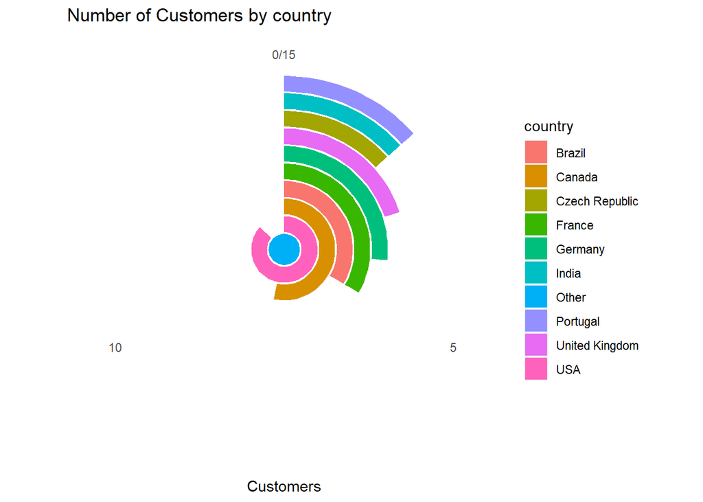

```r
# Plotting the number of customers
ggplot(data = country, aes(x = reorder(country, -n_customer),
                                   y = n_customer,
                                   fill = country)) +
  geom_bar(stat = "identity") +
  coord_polar("y") +
  labs(
    title = "Number of Customers by country",
    x = element_blank(),
    y = "Customers"
  ) + theme( panel.background = element_rect(fill = "white"), axis.text.y = element_blank(), axis.ticks.y = element_blank())
```

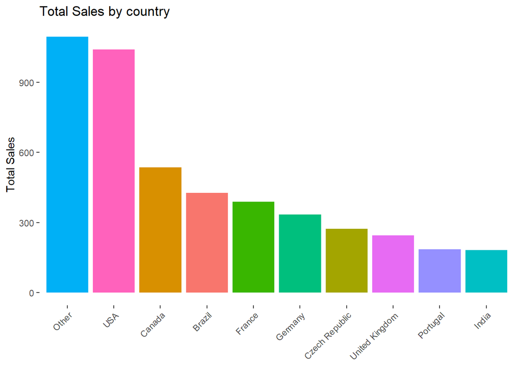

```r
# Plotting total value of customers
ggplot(data = country, aes(x = reorder(country, -total_value),
                                   y = total_value,
                                   fill = country)) +
  geom_bar(stat = "identity") +
  labs(
    title = "Total Sales by country",
    x = element_blank(),
    y = "Total Sales"
  ) + theme(axis.text.x = element_text(angle = 45, hjust = 1), panel.background = element_rect(fill = "white"), legend.position = "none")
```

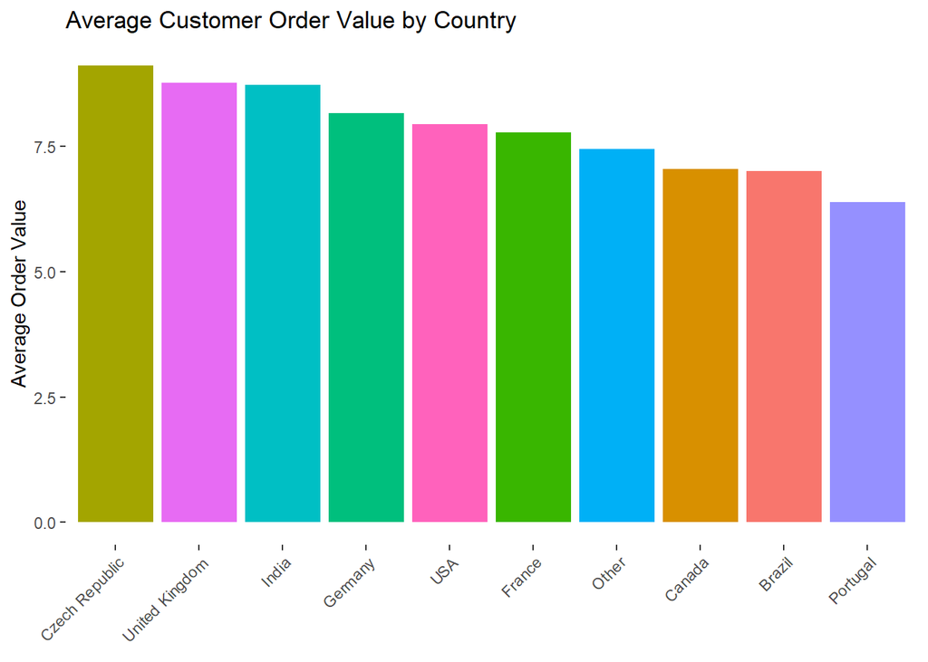

```r
# Plotting the number of customers
ggplot(data = country, aes(x = reorder(country, -average_order_Value),
                                   y = average_order_Value,
                                   fill = country)) +
  geom_bar(stat = "identity") +
  labs(
    title = "Average Customer Order Value by Country",
    x = element_blank(),
    y = "Average Order Value"
  ) + theme(axis.text.x = element_text(angle = 45, hjust = 1), panel.background = element_rect(fill = "white"), legend.position = "none")
```

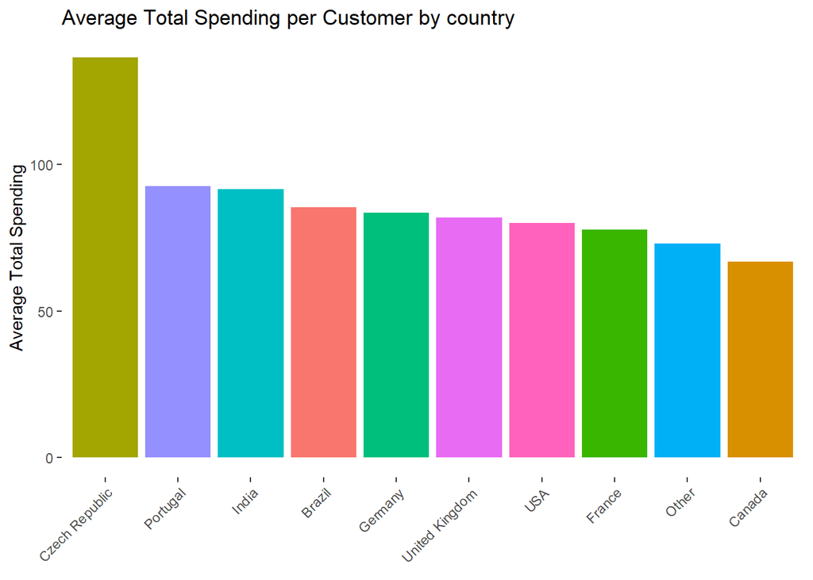

```r
# Plotting average value per customer
ggplot(data = country, aes(x = reorder(country, -average_value_per_customer),
                                   y = average_value_per_customer,
                                   fill = country)) +
  geom_bar(stat = "identity") +
  labs(
    title = "Average Total Spending per Customer by country",
    x = element_blank(),
    y = "Average Total Spending"
  ) + theme(axis.text.x = element_text(angle = 45, hjust = 1), panel.background = element_rect(fill = "white"), legend.position = "none")
```

### 4. Buy albums or tracks?

The last question is whether the company should buy songs in the form of albums or tracks, we will investigate it based on the customer spending habit.

```r
# Writing the query
query4 <- "WITH track_album AS
    (
        SELECT DISTINCT a.album_id,
                        COUNT(DISTINCT t.track_id) track_count
        FROM track t
        INNER JOIN album a ON t.album_id = a.album_id
        GROUP BY a.album_id
    ),

    track_il AS
    (
        SELECT il.invoice_id,
               t.album_id,
               COUNT(DISTINCT il.track_id) track_count
        FROM track t
        INNER JOIN invoice_line il ON il.track_id = t.track_id
        GROUP BY invoice_id, album_id
    )

SELECT purchase_type,
       COUNT(DISTINCT il.invoice_id) invoice_count,
       ROUND(CAST(COUNT(DISTINCT pt.invoice_id) AS FLOAT) / (
                                                       SELECT COUNT(*)
                                                       FROM invoice
                                                             ) * 100, 0) percentage
FROM
   (
        SELECT il.invoice_id,
        CASE WHEN
                til.track_count = ta.track_count THEN 'Album'
                ELSE 'Individual Tracks'
                END AS purchase_type
        FROM invoice_line il
        INNER JOIN track_il til ON il.invoice_id = til.invoice_id
        INNER JOIN track_album ta ON til.album_id = ta.album_id
        GROUP BY il.invoice_id
   ) AS pt
INNER JOIN invoice_line il ON pt.invoice_id = il.invoice_id
GROUP BY purchase_type;
"

# Running the query
album_track <- run_query(query4)

# Previewing the result
album_track
```

```
##       purchase_type invoice_count percentage
## 1             Album           117         19
## 2 Individual Tracks           497         81
```

The table shows that customers prefer to buy songs by the track instead of a full album. Thus it would be wise to create our business model based on that fact.